# Rodrigo Burberg PROJECT 6 AI/ML

Background and Context

Businesses like banks that provide service have to worry about the problem of 'Churn' i.e. customers leaving and joining another service provider. It is important to understand which aspects of the service influence a customer's decision in this regard. Management can concentrate efforts on the improvement of service, keeping in mind these priorities.

Objective

Given a Bank customer, build a neural network-based classifier that can determine whether they will leave or not in the next 6 months.

Data Description

The case study is from an open-source dataset from Kaggle. The dataset contains 10,000 sample points with 14 distinct features such as CustomerId, CreditScore, Geography, Gender, Age, Tenure, Balance, etc.

Data Dictionary

- RowNumber: Row number.
- CustomerId: Unique identification key for different customers.
- Surname: Surname of the customer
- Credit Score: A credit score is a measure of an individual's ability to pay back the borrowed amount. It is the numerical representation of their creditworthiness. A credit score is a 3-digit number that falls in the range of 300-900, 900 being the highest.
- Geography: The country to which the customer belongs.
- Gender: The gender of the customer.
- Age: Age of the customer.
- Tenure: The period of time a customer has been associated with the bank.
- Balance: The account balance (the amount of money deposited in the bank account) of the customer.
- NumOfProducts: How many accounts, bank account affiliated products the person has.
- HasCrCard: Does the customer have a credit card through the bank?
- IsActiveMember: Subjective, but for the concept
- EstimatedSalary: Estimated salary of the customer.
- Exited: Did they leave the bank after all?

Best Practices for Notebook :

The notebook should be well-documented, with inline comments explaining the functionality of code and markdown cells containing comments on the observations and insights. The notebook should be run from start to finish in a sequential manner before submission. It is preferable to remove all warnings and errors before submission. The notebook should be submitted as an HTML file (.html) and as a notebook file (.ipynb)

```python
#importing tensorflow
import tensorflow as tf
print(tf.__version__)
```

```
2.5.0
```

```python
#importing libraries
import pandas as pd
import numpy as np
from sklearn.model_selection import train_test_split
import tensorflow as tf
from sklearn import preprocessing
from tensorflow.keras.models import Sequential
from tensorflow.keras.layers import Dense, Dropout
from tensorflow.keras.optimizers import Adam
from sklearn.metrics import accuracy_score, confusion_matrix, precision_score, recall_score, f1_score, precision_recall_curve, auc
import matplotlib.pyplot as plt
from tensorflow.keras import optimizers
from sklearn.decomposition import PCA
import seaborn as sns
import keras
import tensorflow as tf
from keras import backend as K
from keras.models import Sequential
from keras.layers import Dense, Dropout
from sklearn.preprocessing import StandardScaler
```

```python
#Reads CSV file

bankdf = pd.read_csv("bank.csv")
```

```python
# Displays 1st 10 rows

bankdf.head(10)
```

|  | RowNumber | CustomerId | Surname | CreditScore | Geography | Gender | Age | Tenure | Balance | NumOfProducts | HasCrCard | IsActiveMember | EstimatedSalary | Exited |
| --- | --- | --- | --- | --- | --- | --- | --- | --- | --- | --- | --- | --- | --- | --- |
| 0 | 1 | 15634602 | Hargrave | 619 | France | Female | 42 | 2 | 0.00 | 1 | 1 | 1 | 101348.88 | 1 |
| 1 | 2 | 15647311 | Hill | 608 | Spain | Female | 41 | 1 | 83807.86 | 1 | 0 | 1 | 112542.58 | 0 |
| 2 | 3 | 15619304 | Onio | 502 | France | Female | 42 | 8 | 159660.80 | 3 | 1 | 0 | 113931.57 | 1 |
| 3 | 4 | 15701354 | Boni | 699 | France | Female | 39 | 1 | 0.00 | 2 | 0 | 0 | 93826.63 | 0 |
| 4 | 5 | 15737888 | Mitchell | 850 | Spain | Female | 43 | 2 | 125510.82 | 1 | 1 | 1 | 79084.10 | 0 |
| 5 | 6 | 15574012 | Chu | 645 | Spain | Male | 44 | 8 | 113755.78 | 2 | 1 | 0 | 149756.71 | 1 |
| 6 | 7 | 15592531 | Bartlett | 822 | France | Male | 50 | 7 | 0.00 | 2 | 1 | 1 | 10062.80 | 0 |
| 7 | 8 | 15656148 | Obinna | 376 | Germany | Female | 29 | 4 | 115046.74 | 4 | 1 | 0 | 119346.88 | 1 |
| 8 | 9 | 15792365 | He | 501 | France | Male | 44 | 4 | 142051.07 | 2 | 0 | 1 | 74940.50 | 0 |
| 9 | 10 | 15592389 | H? | 684 | France | Male | 27 | 2 | 134603.88 | 1 | 1 | 1 | 71725.73 | 0 |

```python
#Shows the number of Rows and Columns

bankdf.shape
```

```
(10000, 14)
```

```python
#unique values of features

bankdf.nunique()
```

```
RowNumber          10000
CustomerId         10000
Surname             2932
CreditScore          460
Geography              3
Gender                 2
Age                   70
Tenure                11
Balance             6382
NumOfProducts          4
HasCrCard              2
IsActiveMember         2
EstimatedSalary     9999
Exited                 2
dtype: int64
```

```python
#Checks to see if there are any null values

bankdf.isnull().values.any()
```

```
False
```

```python
bankdf.info()
```

```
<class 'pandas.core.frame.DataFrame'>
RangeIndex: 10000 entries, 0 to 9999
Data columns (total 14 columns):
 #   Column           Non-Null Count  Dtype
---  ------           --------------  -----
 0   RowNumber        10000 non-null  int64
 1   CustomerId       10000 non-null  int64
 2   Surname          10000 non-null  object
 3   CreditScore      10000 non-null  int64
 4   Geography        10000 non-null  object
 5   Gender           10000 non-null  object
 6   Age              10000 non-null  int64
 7   Tenure           10000 non-null  int64
 8   Balance          10000 non-null  float64
 9   NumOfProducts    10000 non-null  int64
 10  HasCrCard        10000 non-null  int64
 11  IsActiveMember   10000 non-null  int64
 12  EstimatedSalary  10000 non-null  float64
 13  Exited           10000 non-null  int64
dtypes: float64(2), int64(9), object(3)
memory usage: 1.1+ MB
```

```python
#Dropping unnessary features

#RowNumber, CustomerId, and Surname do not add any value to the model

bankdf = bankdf.drop(columns= ['RowNumber', 'CustomerId', 'Surname'])
```

```python
bankdf.shape
```

```
(10000, 11)
```

### The most important feature is 'Exited' since this is our target variable

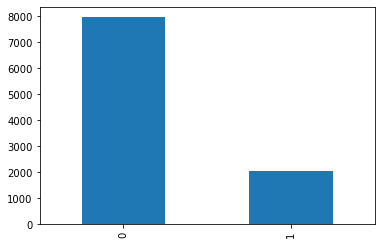

```python
#visual representation of instances per class
bankdf.Exited.value_counts().plot.bar()
```

# EDA

## Univariate analysis

- Continous variables are CreditScore, Age, Tenure, Balance

```python
# function that will help us create boxplot and histogram for any input numerical
# variable.
# This function takes the numerical column as the input and returns the boxplots
# and histograms for the variable.
# Let us see if this help us write faster and cleaner code.
def histogram_boxplot(feature, figsize=(15,10), bins = None):
    """ Boxplot and histogram combined
    feature: 1-d feature array
    figsize: size of fig (default (9,8))
    bins: number of bins (default None / auto)
    """
    f2, (ax_box2, ax_hist2) = plt.subplots(nrows = 2, # Number of rows of the subplot grid= 2
                                           sharex = True, # x-axis will be shared among all subplots
                                           gridspec_kw = {"height_ratios": (.25, .75)},
                                           figsize = figsize
                                           ) # creating the 2 subplots
    sns.boxplot(feature, ax=ax_box2, showmeans=True, color='violet') # boxplot will be created and a star will indicate the mean value of the column
    sns.distplot(feature, kde=F, ax=ax_hist2, bins=bins,palette="winter") if bins else sns.distplot(feature, kde=False, ax=ax_hist2) # For histogram
    ax_hist2.axvline(np.mean(feature), color='green', linestyle='--') # Add mean to the histogram
    ax_hist2.axvline(np.median(feature), color='black', linestyle='-') # Add median to the histogram
```

```python
# Function to create barplots that indicate percentage for each category.

def perc_on_bar(plot, feature):
    '''
    plot
    feature: categorical feature
    the function won't work if a column is passed in hue parameter
    '''

    total = len(feature) # length of the column
    for p in ax.patches:
        percentage = '{:.1f}%'.format(100 * p.get_height()/total) # percentage of each class of the category
        x = p.get_x() + p.get_width() / 2 - 0.05 # width of the plot
        y = p.get_y() + p.get_height()           # hieght of the plot
        ax.annotate(percentage, (x, y), size = 12) # annotate the percantage

    plt.show() # show the plot
```

```python
## Function to plot stacked bar chart
def stacked_plot(x):
    sns.set(palette="nipy_spectral")
    tab1 = pd.crosstab(x, bankdf["Exited"], margins=True)
    print(tab1)
    print("-" * 120)
    tab = pd.crosstab(x, bankdf["Exited"], normalize="index")
    tab.plot(kind="bar", stacked=True, figsize=(10, 5))
    # plt.legend(loc='lower left', frameon=False)
    # plt.legend(loc="upper left", bbox_to_anchor=(0,1))
    plt.show()
```

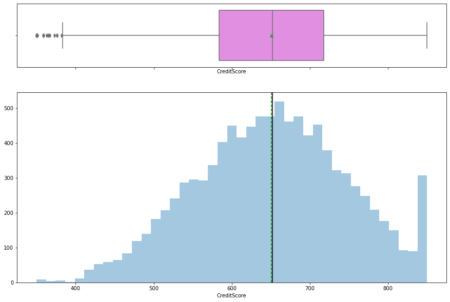

```python
histogram_boxplot(bankdf['CreditScore'])
```

- Credit score data is negatively skewed. The data also shows that there are about 300 clients with a perfect credit score

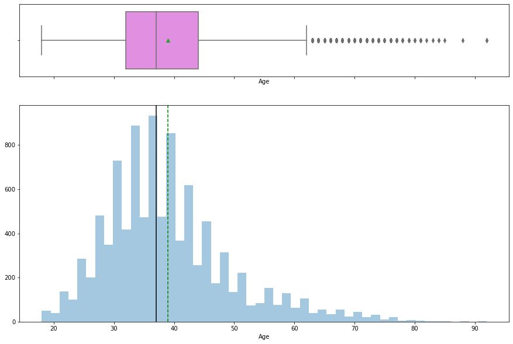

```python
histogram_boxplot(bankdf['Age'])
```

- Age dat is positively skewed. We will not treat any of the outliers since they are representative of the real world.

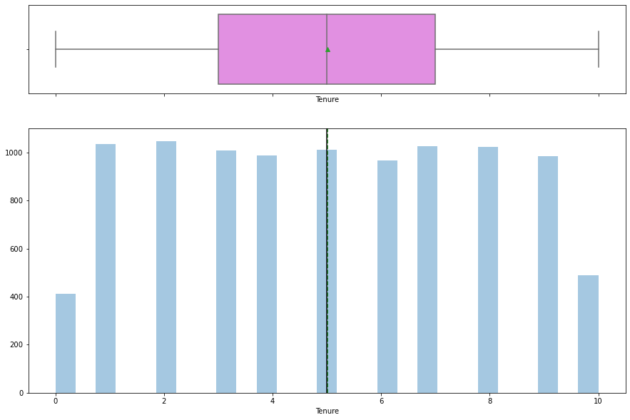

```python
histogram_boxplot(bankdf['Tenure'])
```

- Tenure data is balanced years 1-9 have each about 1000 clients, while years 0 and 10 have the lowest of bout 400 and 500 respectively.

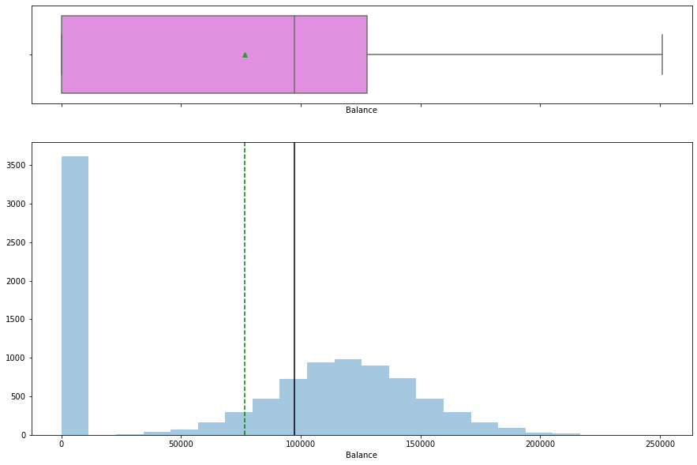

```python
histogram_boxplot(bankdf['Balance'])
```

- Balance data is evenly distributed, but has a high number of clients having a ZERO balance.

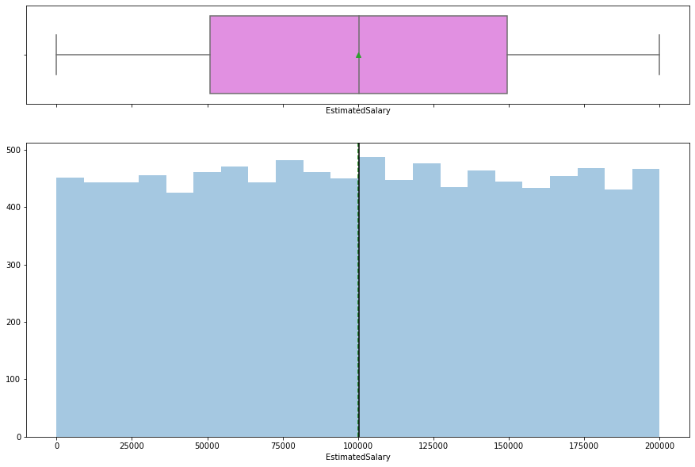

```python
histogram_boxplot(bankdf['EstimatedSalary'])
```

- Estimated salary is around 450 for all the categories

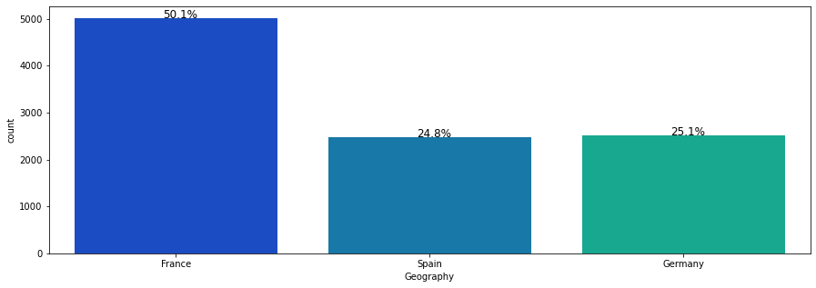

```python
plt.figure(figsize=(15,5))
ax = sns.countplot(bankdf["Geography"],palette='winter')
perc_on_bar(ax,bankdf["Geography"])
```

- First: France 50.1%
- Second: Germany 25.1%
- Third: Spain 24.8%

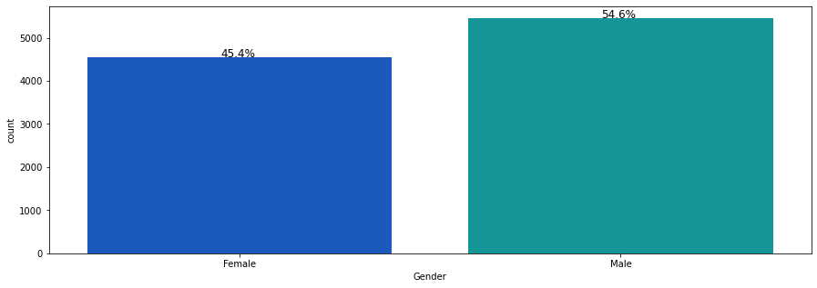

```python
plt.figure(figsize=(15,5))
ax = sns.countplot(bankdf["Gender"],palette='winter')
perc_on_bar(ax,bankdf["Gender"])
```

- 45.4% FEMALE
- 54.6% MALE

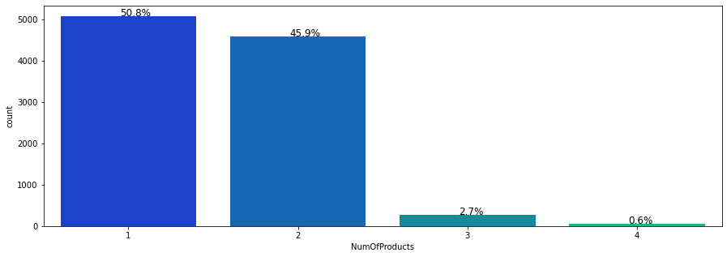

```python
plt.figure(figsize=(15,5))
ax = sns.countplot(bankdf["NumOfProducts"],palette='winter')
perc_on_bar(ax,bankdf["NumOfProducts"])
```

- 1 - 50.8%
- 2 - 45.9%
- 3 - 2.7%
- 4 - 0.6%

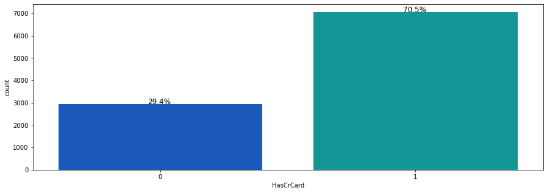

```python
plt.figure(figsize=(15,5))
ax = sns.countplot(bankdf["HasCrCard"],palette='winter')
perc_on_bar(ax,bankdf["HasCrCard"])
```

- Do not have a credit card - 29.4%
- Have credit card -70.5%

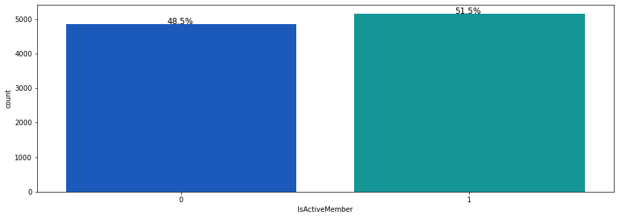

```python
plt.figure(figsize=(15,5))
ax = sns.countplot(bankdf["IsActiveMember"],palette='winter')
perc_on_bar(ax,bankdf["IsActiveMember"])
```

- 48.5% - are not active members
- 51.5% - are active members

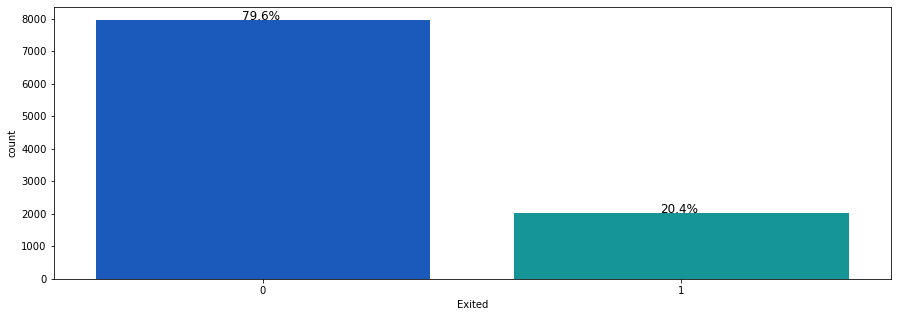

```python
plt.figure(figsize=(15,5))
ax = sns.countplot(bankdf["Exited"],palette='winter')
perc_on_bar(ax,bankdf["Exited"])
```

- Exited - 20.4%
- Not Exited - 79.6%

## Bivariate analysis

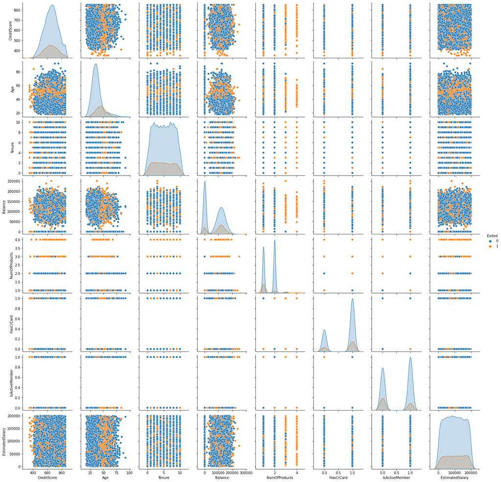

```python
sns.pairplot(bankdf, hue="Exited")
```

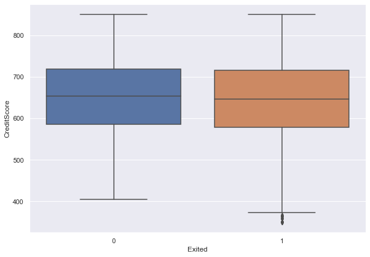

```python
#CreditScrore vs Exited

sns.set(rc={"figure.figsize": (10, 7)})
sns.boxplot(x="Exited", y="CreditScore", data=bankdf, orient="vertical")
```

- Those clients that existed vs those that didnt have the same credit scores

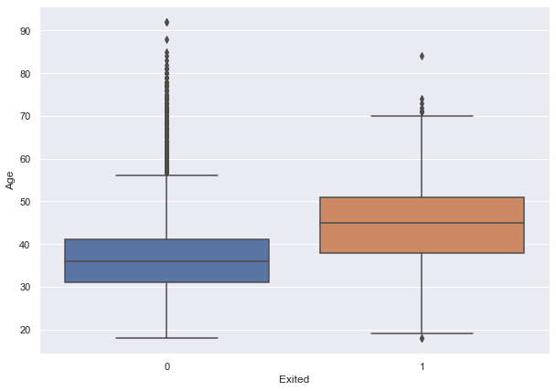

```python
#Age vs Exited

sns.set(rc={"figure.figsize": (10, 7)})
sns.boxplot(x="Exited", y="Age", data=bankdf, orient="vertical")
```

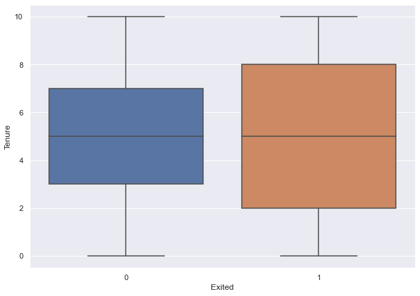

```python
#Tenure vs Exited

sns.set(rc={"figure.figsize": (10, 7)})
sns.boxplot(x="Exited", y="Tenure", data=bankdf, orient="vertical")
```

- Very similay data, but the 50th percentile of the NOT Exited is between 3 to 7 years while those of the Exited are between years 2 and 8

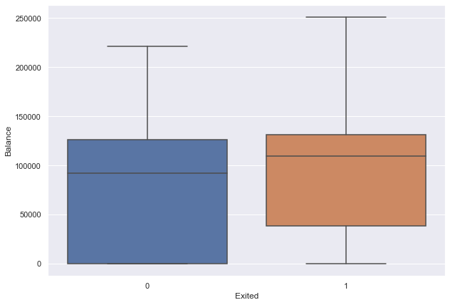

```python
#Balance vs Exited

sns.set(rc={"figure.figsize": (10, 7)})
sns.boxplot(x="Exited", y="Balance", data=bankdf, orient="vertical")
```

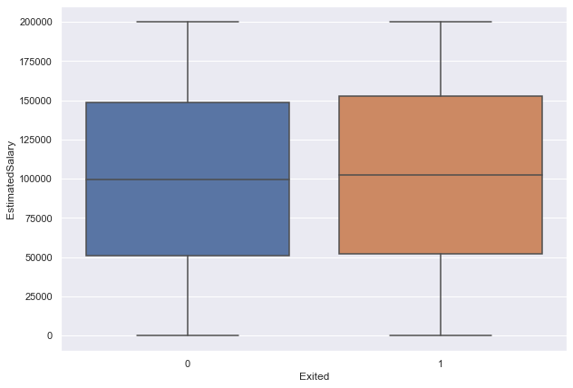

```python
#EstimatedSalary vs Exited

sns.set(rc={"figure.figsize": (10, 7)})
sns.boxplot(x="Exited", y="EstimatedSalary", data=bankdf, orient="vertical")
```

- Estmiated salary is the same for Exited and Not Exited

```
Exited        0     1    All
Geography
France     4204   810   5014
Germany    1695   814   2509
Spain      2064   413   2477
All        7963  2037  10000
------------------------------------------------------------------------------------------------------------------------
```

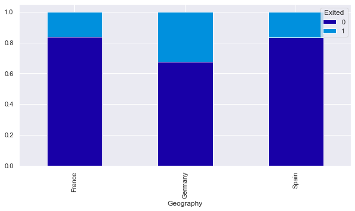

```python
stacked_plot(bankdf["Geography"])
```

- Germany had the highest Exited percentage
- France and Spain had almost the same exit rate

```
Exited     0     1    All
Gender
Female  3404  1139   4543
Male    4559   898   5457
All     7963  2037  10000
------------------------------------------------------------------------------------------------------------------------
```

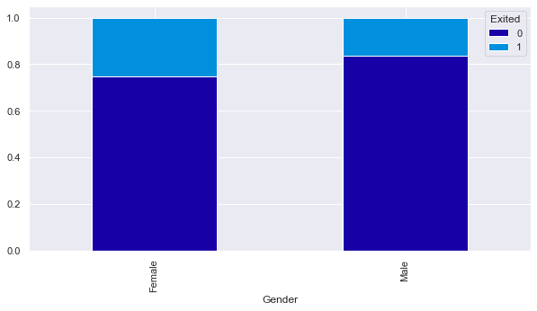

```python
stacked_plot(bankdf["Gender"])
```

- Females in general exited more than males

```
Exited            0     1    All
NumOfProducts
1              3675  1409   5084
2              4242   348   4590
3                46   220    266
4                 0    60     60
All            7963  2037  10000
------------------------------------------------------------------------------------------------------------------------
```

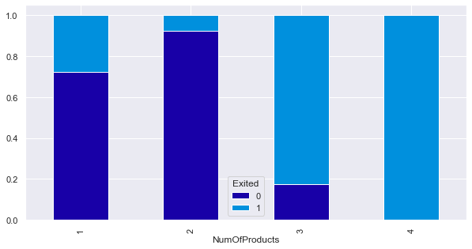

```python
stacked_plot(bankdf["NumOfProducts"])
```

- clients with 1 or 2 products had a high chance of not existing
- clients with 3 products had a high probablility of leaving ~ 82%
- clients with 4 products all exited
- The bank should not offer more products if the client already has 2 products because clients with 3 or more products tend to leave

```
Exited        0     1    All
HasCrCard
0          2332   613   2945
1          5631  1424   7055
All        7963  2037  10000
------------------------------------------------------------------------------------------------------------------------
```

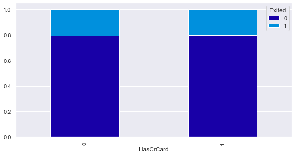

```python
stacked_plot(bankdf["HasCrCard"])
```

- This is the same for groups that exited vs those that didn't

```
Exited             0     1    All
IsActiveMember
0               3547  1302   4849
1               4416   735   5151
All             7963  2037  10000
------------------------------------------------------------------------------------------------------------------------
```

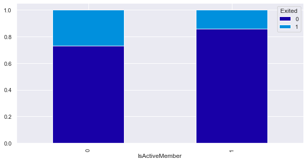

```python
stacked_plot(bankdf["IsActiveMember"])
```

- Those that are active members are more likely to stay

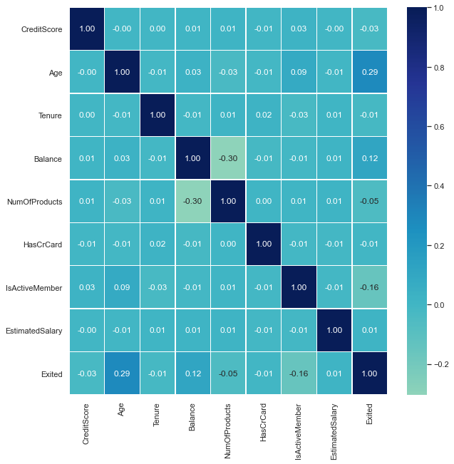

```python
#heatmap

sns.set(rc={"figure.figsize": (10, 10)})
sns.heatmap(
    bankdf.corr(),
    annot=True,
    linewidths=0.5,
    center=0,
    cbar=True,
    cmap="YlGnBu",
    fmt="0.2f",
)
plt.show()
```

```python
#Create dummy variables for Geography and Gender

bankdf = pd.get_dummies(bankdf, columns=['Geography'])

bankdf = pd.get_dummies(bankdf, columns=['Gender'])
```

```python
bankdf.head()
```

|  | CreditScore | Age | Tenure | Balance | NumOfProducts | HasCrCard | IsActiveMember | EstimatedSalary | Exited | Geography_France | Geography_Germany | Geography_Spain | Gender_Female | Gender_Male |
| --- | --- | --- | --- | --- | --- | --- | --- | --- | --- | --- | --- | --- | --- | --- |
| 0 | 619 | 42 | 2 | 0.00 | 1 | 1 | 1 | 101348.88 | 1 | 1 | 0 | 0 | 1 | 0 |
| 1 | 608 | 41 | 1 | 83807.86 | 1 | 0 | 1 | 112542.58 | 0 | 0 | 0 | 1 | 1 | 0 |
| 2 | 502 | 42 | 8 | 159660.80 | 3 | 1 | 0 | 113931.57 | 1 | 1 | 0 | 0 | 1 | 0 |
| 3 | 699 | 39 | 1 | 0.00 | 2 | 0 | 0 | 93826.63 | 0 | 1 | 0 | 0 | 1 | 0 |
| 4 | 850 | 43 | 2 | 125510.82 | 1 | 1 | 1 | 79084.10 | 0 | 0 | 0 | 1 | 1 | 0 |

```python
#SPLITTING DATA

# Specify the data
X=bankdf.drop(columns='Exited')

# Specify the target labels and flatten array
y= bankdf.Exited


# Split the data up in train and test sets
X_train, X_test, y_train, y_test = train_test_split(X, y, test_size=0.30, random_state=42)

y_train =  np.array(y_train)
y_test =  np.array(y_test)
```

```python
print(X.shape)
print(y.shape)
```

```
(10000, 13)
(10000,)
```

```python
#SCALING DATA

# Define the scaler
scaler = StandardScaler().fit(X_train)

# Scale the train set
X_train = scaler.transform(X_train)

# Scale the test set
X_test = scaler.transform(X_test)
```

# Deep Neural Network

```python
# Initialize the constructor
model = Sequential()


# This adds the input layer (by specifying input dimension) AND the first hidden layer (units)
model.add(Dense(units=12, input_dim = 13,activation='relu'))
# hidden layer
model.add(Dense(units=13,activation='relu'))
#Adding Dropout to prevent overfitting
model.add(Dropout(0.5))
model.add(Dense(10,activation='relu'))
model.add(Dense(10,activation='relu'))
# Adding the output layer
# Notice that we do not need to specify input dim.
# we have an output of 1 node, which is the the desired dimensions of our output (Exited or not)
# We use the sigmoid because we want probability outcomes
model.add(Dense(1,activation='sigmoid'))                        # binary classification Exited or not
```

```python
# Create optimizer with default learning rate
# Compile the model
model.compile(optimizer='adam',loss='binary_crossentropy',metrics=['accuracy'])
```

```python
model.summary()
```

```
Model: "sequential_28"
_________________________________________________________________
Layer (type)                 Output Shape              Param #
=================================================================
dense_128 (Dense)            (None, 12)                168
_________________________________________________________________
dense_129 (Dense)            (None, 13)                169
_________________________________________________________________
dropout_34 (Dropout)         (None, 13)                0
_________________________________________________________________
dense_130 (Dense)            (None, 10)                140
_________________________________________________________________
dense_131 (Dense)            (None, 10)                110
_________________________________________________________________
dense_132 (Dense)            (None, 1)                 11
=================================================================
Total params: 598
Trainable params: 598
Non-trainable params: 0
_________________________________________________________________
```

```python
#fitting the model
history=model.fit(X_train,y_train,batch_size=15,epochs=20,validation_split=0.3)
```

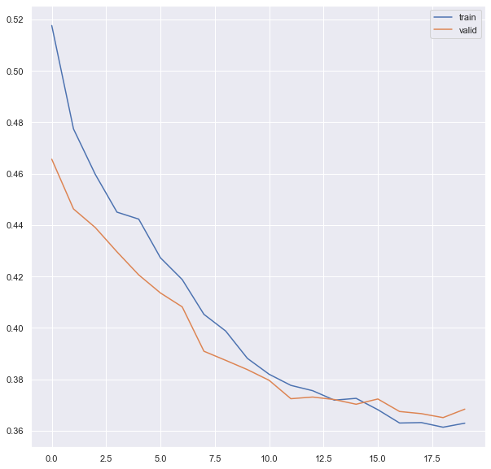

```python
# Capturing learning history per epoch
hist  = pd.DataFrame(history.history)
hist['epoch'] = history.epoch

# Plotting accuracy at different epochs
plt.plot(hist['loss'])
plt.plot(hist['val_loss'])
plt.legend(("train" , "valid") , loc =0)
```

- As we can see the loss of the test and validation sets converge around the 15 epoch

```python
score = model.evaluate(X_test, y_test)
```

```python
print(score)
```

```
[0.35426265001296997, 0.8650000095367432]
```

```python
def make_confusion_matrix(cf,
                          group_names=None,
                          categories='auto',
                          count=True,
                          percent=True,
                          cbar=True,
                          xyticks=True,
                          xyplotlabels=True,
                          sum_stats=True,
                          figsize=None,
                          cmap='Blues',
                          title=None):
    '''
    This function will make a pretty plot of an sklearn Confusion Matrix cm using a Seaborn heatmap visualization.
    Arguments
    '''


    # CODE TO GENERATE TEXT INSIDE EACH SQUARE
    blanks = ['' for i in range(cf.size)]

    if group_names and len(group_names)==cf.size:
        group_labels = ["{}\n".format(value) for value in group_names]
    else:
        group_labels = blanks

    if count:
        group_counts = ["{0:0.0f}\n".format(value) for value in cf.flatten()]
    else:
        group_counts = blanks

    if percent:
        group_percentages = ["{0:.2%}".format(value) for value in cf.flatten()/np.sum(cf)]
    else:
        group_percentages = blanks

    box_labels = [f"{v1}{v2}{v3}".strip() for v1, v2, v3 in zip(group_labels,group_counts,group_percentages)]
    box_labels = np.asarray(box_labels).reshape(cf.shape[0],cf.shape[1])


    # CODE TO GENERATE SUMMARY STATISTICS & TEXT FOR SUMMARY STATS
    if sum_stats:
        #Accuracy is sum of diagonal divided by total observations
        accuracy  = np.trace(cf) / float(np.sum(cf))

        #if it is a binary confusion matrix, show some more stats
        if len(cf)==2:
            #Metrics for Binary Confusion Matrices
            precision = cf[1,1] / sum(cf[:,1])
            recall    = cf[1,1] / sum(cf[1,:])
            f1_score  = 2*precision*recall / (precision + recall)
            stats_text = "\n\nAccuracy={:0.3f}\nPrecision={:0.3f}\nRecall={:0.3f}\nF1 Score={:0.3f}".format(
                accuracy,precision,recall,f1_score)
        else:
            stats_text = "\n\nAccuracy={:0.3f}".format(accuracy)
    else:
        stats_text = ""


    # SET FIGURE PARAMETERS ACCORDING TO OTHER ARGUMENTS
    if figsize==None:
        #Get default figure size if not set
        figsize = plt.rcParams.get('figure.figsize')

    if xyticks==False:
        #Do not show categories if xyticks is False
        categories=False


    # MAKE THE HEATMAP VISUALIZATION
    plt.figure(figsize=figsize)
    sns.heatmap(cf,annot=box_labels,fmt="",cmap=cmap,cbar=cbar,xticklabels=categories,yticklabels=categories)

    if xyplotlabels:
        plt.ylabel('True label')
        plt.xlabel('Predicted label' + stats_text)
    else:
        plt.xlabel(stats_text)

    if title:
        plt.title(title)
```

[figure not shown]

```python
## Confusion Matrix on unsee test set
import seaborn as sn
y_pred1 = model2.predict(X_test)
for i in range(len(y_test)):
    if y_pred1[i]>0.5:
        y_pred1[i]=1
    else:
        y_pred1[i]=0



cm=confusion_matrix(y_test, y_pred1)
labels = ['True Negative','False Positive','False Negative','True Positive']
categories = [ 'Not Exited','Exited']
make_confusion_matrix(cm,
                      group_names=labels,
                      categories=categories,
                      cmap='Blues')
```

- The first model performed well. We are mostly concerned about accuracy and recall. With recall we want to minimize the number of false negatives.

```python
## Build new model

# Initialize the constructor
model2 = Sequential()


# This adds the input layer (by specifying input dimension) AND the first hidden layer (units)
model2.add(Dense(units=15, input_dim = 13,activation='relu'))   # input of 13 columns as shown above
# hidden layer
model.add(Dense(units=13,activation='relu'))
#Adding Dropout to prevent overfitting
model2.add(Dropout(0.3))
model2.add(Dense(20,activation='relu'))
model2.add(Dense(20,activation='relu'))
model2.add(Dense(14,activation='relu'))
# Adding the output layer
# Notice that we do not need to specify input dim.
# we have an output of 1 node, which is the the desired dimensions of our output (fraud or not)
# We use the sigmoid because we want probability outcomes
model2.add(Dense(1,activation='sigmoid'))                        # binary classification Exited or not
```

```python
# Create optimizer with default learning rate
# Compile the model
model2.compile(optimizer='adam',loss='binary_crossentropy',metrics=['accuracy'])
```

```python
#fitting the model
history2=model2.fit(X_train,y_train,batch_size=15,epochs=20,validation_split=0.2)
```

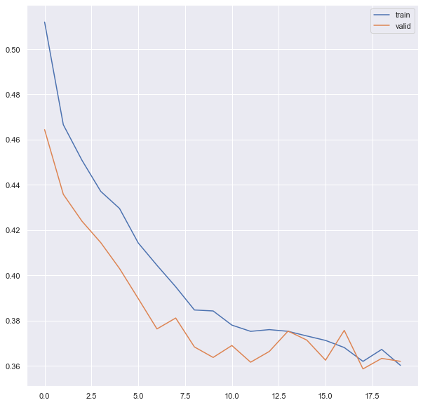

```python
# Capturing learning history per epoch
hist  = pd.DataFrame(history2.history)
hist['epoch'] = history2.epoch

# Plotting accuracy at different epochs
plt.plot(hist['loss'])
plt.plot(hist['val_loss'])
plt.legend(("train" , "valid") , loc =0)
```

- The model converged around epoch 11

[figure not shown]

```python
## Confusion Matrix on unsee test set
import seaborn as sn
y_pred1 = model2.predict(X_test)
for i in range(len(y_test)):
    if y_pred1[i]>0.5:
        y_pred1[i]=1
    else:
        y_pred1[i]=0



cm3=confusion_matrix(y_test, y_pred1)
labels = ['True Negative','False Positive','False Negative','True Positive']
categories = [ 'Not_Fraud','Fraud']
make_confusion_matrix(cm2,
                      group_names=labels,
                      categories=categories,
                      cmap='Blues')
```

```python
# MODEL 3

#Training Multi-layer perceptron with 2 hidden layers

#adding earlystopping callback
es= keras.callbacks.EarlyStopping(monitor='val_loss',
                              min_delta=0,
                              patience=15,

                             verbose=0, mode='min', restore_best_weights= True)
Model3 = Sequential()
#Initializing the weights uisng hue_normal
Model3.add(Dense(65, input_dim = 13 , kernel_initializer='he_normal', activation='relu'))
Model3.add(Dropout(0.5))
Model3.add(Dense(65, kernel_initializer='he_normal', activation='relu'))
Model3.add(Dropout(0.5))
Model3.add(Dense(1, kernel_initializer='he_normal', activation='sigmoid'))

Model3.compile(optimizer = 'adam', loss='binary_crossentropy', metrics=['accuracy'])

history3= Model3.fit(X_train, y_train, validation_split=0.3, batch_size=700, epochs=40, callbacks=[es], shuffle=True, verbose=1)
```

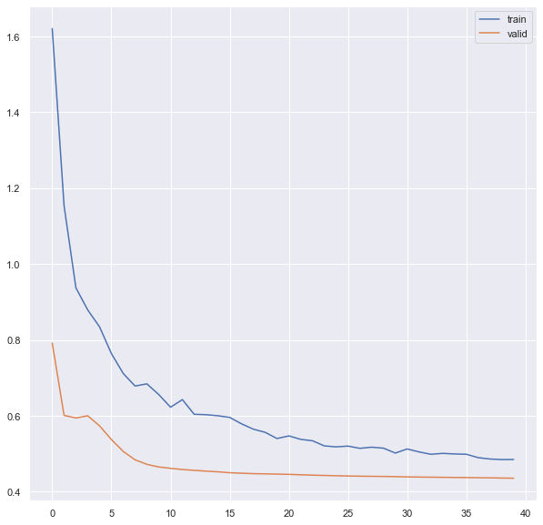

```python
# Capturing learning history per epoch
hist3  = pd.DataFrame(history3.history)
hist3['epoch'] = history3.epoch

# Plotting accuracy at different epochs
plt.plot(hist3['loss'])
plt.plot(hist3['val_loss'])
plt.legend(("train" , "valid") , loc =0)
```

- Model 3 started to converge around epoch 18

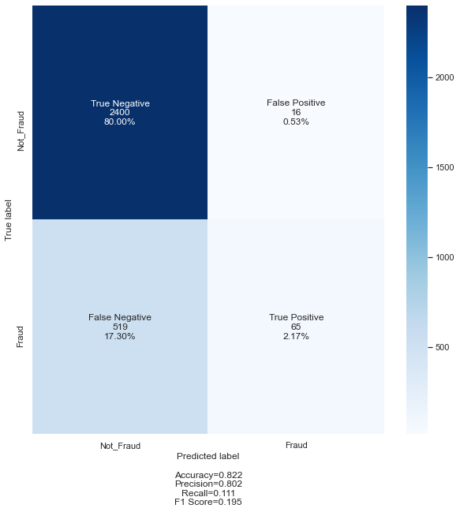

```python
## Confusion Matrix on unsee test set
import seaborn as sn
y_pred1 = Model3.predict(X_test)
for i in range(len(y_test)):
    if y_pred1[i]>0.5:
        y_pred1[i]=1
    else:
        y_pred1[i]=0



cm3=confusion_matrix(y_test, y_pred1)
labels = ['True Negative','False Positive','False Negative','True Positive']
categories = [ 'Not_Fraud','Fraud']
make_confusion_matrix(cm3,
                      group_names=labels,
                      categories=categories,
                      cmap='Blues')
```

- Model 3 performed better than model 2 but worse than model 1.

# Conclusion and key takeaways

- Model 1 performed the best out of all the models.
- We can change the arcitechure of the Nueral Network and try to see if the models perform better
- With this model the bank can use it to see if a client might exit in the future. The bank should give promotions and/or incentives for the client to stay.
- In our models we want to focus on recall, since we want to reduce the False Negatives. The False Negatives would tell the bank that a customer is not leaving when they actually are. If this is the case the bank will not target these clients which will Exit.
- One key insight from the EDA performed is that clients with more than 2 products are HIGHlY likely to exit.